# Model Planning and Building

Albert Swingler

For this phase of the project I want use the the data I scraped from Pew Research Centers website that has the immigration information of congresspeople in the House and the Senate. One question I want to answer is weather there is a corelation between a congressperson being a immigrant and their party and how they vote on bills.

115th: https://www.pewresearch.org/fact-tank/2018/08/21/immigrants-or-children-of-immigrants-make-up-at-least-12-of-congress/

116th: https://www.pewresearch.org/fact-tank/2019/01/24/in-116th-congress-at-least-13-of-lawmakers-are-immigrants-or-the-children-of-immigrants/

Here I imported the data from the tables on the two websites and created two tibbles with it.

```r
library("tidyverse")
library("rvest")
library("dplyr")
library("knitr")
library("caret")
purl("deliverable1.Rmd", output = "part1.r") # produces r source from rmd
```

```
processing file: deliverable1.Rmd
```

[output not shown]

```
output file: part1.r
```

```
[1] "part1.r"
```

```r
source("part1.r") # executes the source
congress115 <- read_html("https://www.pewresearch.org/fact-tank/2018/08/21/immigrants-or-children-of-immigrants-make-up-at-least-12-of-congress/")
congress116 <- read_html("https://www.pewresearch.org/fact-tank/2019/01/24/in-116th-congress-at-least-13-of-lawmakers-are-immigrants-or-the-children-of-immigrants/")



names115 <- congress115 %>% html_nodes("tr > td:nth-child(1)") %>% html_text()

generation115 <- congress115 %>% html_nodes("tr > td:nth-child(2)") %>% html_text()

birthplace115 <- congress115 %>% html_nodes("tr > td:nth-child(3)") %>% html_text()

office115 <- congress115 %>% html_nodes("tr > td:nth-child(4)") %>% html_text()

party115 <- congress115 %>% html_nodes("tr > td:nth-child(5)") %>% html_text()

states115 <- congress115 %>% html_nodes("tr > td:nth-child(6)") %>% html_text()

c115Tibble <- tibble(Name = names115, generation = generation115, Parent_or_Members_birthplace = birthplace115, Chamber = office115, Party = party115, State = states115)



names116 <- congress116 %>% html_nodes("tr > td:nth-child(1)") %>% html_text()

generation116 <- congress116 %>% html_nodes("tr > td:nth-child(2)") %>% html_text()

birthplace116 <- congress116 %>% html_nodes("tr > td:nth-child(3)") %>% html_text()

office116 <- congress116 %>% html_nodes("tr > td:nth-child(5)") %>% html_text()

party116 <- congress116 %>% html_nodes("tr > td:nth-child(4)") %>% html_text()

states116 <- congress116 %>% html_nodes("tr > td:nth-child(6)") %>% html_text()

c116Tibble <- tibble(Name = names116, generation = generation116, Parent_or_Members_birthplace = birthplace116, Chamber = office116, Party = party116, State = states116)
```

Cleaning data:

```r
c115Tibble$Party <- substr(c115Tibble$Party, 0, 1)
c116Tibble$Party <- substr(c116Tibble$Party, 0, 1)


c115Tibble <- mutate_if(c115Tibble,
is.character, str_replace_all, pattern = "First", replacement = "1")

c115Tibble <- mutate_if(c115Tibble,
is.character, str_replace_all, pattern = "Second", replacement = "2")


as.numeric(as.character(c115Tibble$generation))
```

```
 [1] 2 2 2 2 2 2 2 2 2 1 2 2 2 2 2 2 2 2 2 2 2 2 2 1 2 2 2 2 2 2 1 2 1 2 1 2 1 1 2 2 2 2 2 1 2 2 2 1 2 1 2 2 2 2 2 1 2 2 2 1 2 2 2 2
```

```r
c116Tibble <- mutate_if(c116Tibble,
is.character, str_replace_all, pattern = "Immigrant", replacement = "1")

c116Tibble <- mutate_if(c116Tibble,
is.character, str_replace_all, pattern = "Child", replacement = "2")


as.numeric(as.character(c116Tibble$generation))
```

```
 [1] 2 2 2 2 2 2 2 2 2 1 2 2 2 2 2 2 2 2 2 2 2 2 1 2 1 2 2 2 2 2 2 1 2 2 2 1 2 2 2 1 1 2 1 2 2 2 1 1 2 2 1 2 2 2 1 2 2 2 2 2 1 2 2 2
[65] 2 1 2 2
```

```r
c115Tibble <- mutate_if(c115Tibble,
is.character, str_replace_all, pattern = "Representative", replacement = "house")

c115Tibble <- mutate_if(c115Tibble,
is.character, str_replace_all, pattern = "Senator", replacement = "senate")

c116Tibble <- mutate_if(c116Tibble,
is.character, str_replace_all, pattern = "Representative", replacement = "house")

c116Tibble <- mutate_if(c116Tibble,
is.character, str_replace_all, pattern = "Senator", replacement = "senate")
```

Relaced the full word for the persons party with just the first letter to match existing data.

Making the persons generation a number instead of first/second and child/immigrant.

Everyone who is not a first or 2nd generation immigrant was given the generation number 3 because I do not have data for how many generations non recently immigrated congresspeople have been Americans.

Switch “Representative” to “house” and “Senator” to “senate” to match existing data.

Setting the generation in the politician tibble to the correct values. Ended up doing this manually after spending days trying to figure out a better way to do this.

```r
politition_with_generation <- merge(c115Tibble, c116Tibble)

#changing the name column so its the same as the other data frames so I can merge the generation numbers into those tables
politition_with_generation$Name <- gsub("\\,.*","", politition_with_generation$Name)
colnames(politition_with_generation)[colnames(politition_with_generation) == "Name"] <- "last_name"

#replacing the generation number in politician with the number from politition_with_generation

#which(politician$last_name=="Clarke")
#gets the row number. had to use since search wont show the actual row number.

politician[4,"generation"]=2
politician[5,"generation"]=2
politician[6,"generation"]=2

politician[128,"generation"]=2
politician[129,"generation"]=2
politician[130,"generation"]=2

politician[1436,"generation"]=2
politician[1437,"generation"]=2
politician[1438,"generation"]=2

politician[95,"generation"]=2
politician[96,"generation"]=2
politician[96,"generation"]=2

politician[1439,"generation"]=2
politician[1440,"generation"]=2
politician[1441,"generation"]=2

politician[116,"generation"]=2
politician[117,"generation"]=2
politician[118,"generation"]=2

politician[47,"generation"]=2
politician[48,"generation"]=2
politician[49,"generation"]=2


politician[275,"generation"]=1
politician[276,"generation"]=1
politician[277,"generation"]=1

politician[248,"generation"]=2
politician[249,"generation"]=2
politician[250,"generation"]=2

politician[223,"generation"]=2
politician[224,"generation"]=2
politician[225,"generation"]=2

politician[204,"generation"]=2
politician[205,"generation"]=2
politician[206,"generation"]=2

politician[269,"generation"]=2
politician[270,"generation"]=2
politician[271,"generation"]=2

politician[1486,"generation"]=2
politician[1487,"generation"]=2
politician[1488,"generation"]=2

politician[198,"generation"]=2
politician[199,"generation"]=2
politician[200,"generation"]=2

politician[309,"generation"]=2
politician[310,"generation"]=2
politician[311,"generation"]=2

politician[323,"generation"]=2
politician[324,"generation"]=2
politician[325,"generation"]=2

politician[1500,"generation"]=2
politician[1501,"generation"]=2
politician[1502,"generation"]=2

politician[1492,"generation"]=2
politician[1493,"generation"]=2
politician[1494,"generation"]=2

politician[378,"generation"]=2
politician[379,"generation"]=2
politician[380,"generation"]=2

politician[391,"generation"]=1
politician[392,"generation"]=1
politician[393,"generation"]=1

politician[484,"generation"]=2
politician[485,"generation"]=2
politician[486,"generation"]=2

politician[510,"generation"]=2
politician[511,"generation"]=2
politician[512,"generation"]=2

politician[452,"generation"]=2
politician[453,"generation"]=2
politician[454,"generation"]=2

politician[1546,"generation"]=2
politician[1547,"generation"]=2
politician[1548,"generation"]=2

politician[548,"generation"]=2
politician[549,"generation"]=2
politician[550,"generation"]=2

politician[1538,"generation"]=2
politician[1539,"generation"]=2
politician[1540,"generation"]=2

politician[1535,"generation"]=1
politician[1536,"generation"]=1
politician[1537,"generation"]=1

politician[530,"generation"]=2
politician[531,"generation"]=2
politician[532,"generation"]=2

politician[641,"generation"]=1
politician[642,"generation"]=1
politician[643,"generation"]=1

politician[699,"generation"]=2
politician[700,"generation"]=2
politician[701,"generation"]=2

politician[682,"generation"]=2
politician[683,"generation"]=2
politician[684,"generation"]=2

politician[704,"generation"]=1
politician[705,"generation"]=1
politician[706,"generation"]=1

politician[781,"generation"]=1
politician[782,"generation"]=1
politician[783,"generation"]=1

politician[773,"generation"]=2
politician[774,"generation"]=2
politician[775,"generation"]=2

politician[1600,"generation"]=2
politician[1601,"generation"]=2
politician[1602,"generation"]=2

politician[869,"generation"]=2
politician[870,"generation"]=2
politician[871,"generation"]=2

politician[1612,"generation"]=1
politician[1613,"generation"]=1
politician[1614,"generation"]=1

politician[927,"generation"]=2
politician[928,"generation"]=2
politician[929,"generation"]=2

politician[1630,"generation"]=2
politician[1631,"generation"]=2
politician[1632,"generation"]=2

politician[1645,"generation"]=2
politician[1646,"generation"]=2
politician[1647,"generation"]=2

politician[1648,"generation"]=2
politician[1649,"generation"]=2
politician[1650,"generation"]=2

politician[1083,"generation"]=1
politician[1084,"generation"]=1
politician[1085,"generation"]=1

politician[1159,"generation"]=2
politician[1160,"generation"]=2
politician[1161,"generation"]=2

politician[1658,"generation"]=2
politician[1659,"generation"]=2
politician[1660,"generation"]=2

politician[1148,"generation"]=2
politician[1149,"generation"]=2
politician[1150,"generation"]=2

politician[1680,"generation"]=2
politician[1681,"generation"]=2
politician[1682,"generation"]=2

politician[1165,"generation"]=1
politician[1166,"generation"]=1
politician[1167,"generation"]=1

politician[1176,"generation"]=2
politician[1177,"generation"]=2
politician[1178,"generation"]=2

politician[1219,"generation"]=2
politician[1220,"generation"]=2
politician[1221,"generation"]=2

politician[1696,"generation"]=2
politician[1697,"generation"]=2
politician[1698,"generation"]=2

politician[1278,"generation"]=1
politician[1279,"generation"]=1
politician[1280,"generation"]=1

politician[1312,"generation"]=2
politician[1313,"generation"]=2
politician[1314,"generation"]=2

politician[1717,"generation"]=2
politician[1718,"generation"]=2
politician[1719,"generation"]=2


summary(politician)
```

```
  last_name            congress        chamber            num_votes         state              district       party
 Length:1731        Min.   :  0.00   Length:1731        Min.   :  1.00   Length:1731        Min.   : 0.0   Length:1731
 Class :character   1st Qu.:  0.00   Class :character   1st Qu.: 45.00   Class :character   1st Qu.: 3.0   Class :character
 Mode  :character   Median :115.00   Mode  :character   Median : 90.00   Mode  :character   Median : 6.0   Mode  :character
                    Mean   : 72.46                      Mean   : 80.33                      Mean   :10.2
                    3rd Qu.:116.00                      3rd Qu.: 96.00                      3rd Qu.:13.0
                    Max.   :116.00                      Max.   :141.00                      Max.   :53.0
                                                                                            NA's   :319
   generation
 Min.   :1.000
 1st Qu.:3.000
 Median :3.000
 Mean   :2.891
 3rd Qu.:3.000
 Max.   :3.000
```

Graphing

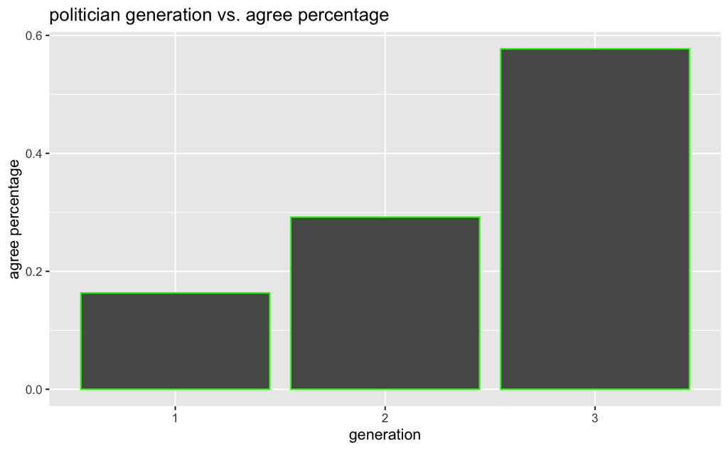

```r
averages <- add_column(averages, politician$generation)
colnames(averages)[colnames(averages) == "politician$generation"] <- "generation"



 averages$generation <- as.factor(averages$generation)
# levels(averages$generation)
#
# averages$agree_pct <- as.factor(averages$agree_pct)
# levels(averages$agree_pct)

# avg_pct_vote_by_gen <- ggplot(averages, aes(generation, agree_pct)) + geom_bar(stat="identity", width=.5, color="green") + theme(axis.text.x = element_text(angle = 0))
avg_pct_vote_by_gen <- ggplot(averages, aes(x=generation, y=agree_pct)) + stat_summary(fun.y="mean", geom="bar", color="green") + ylab("agree percentage") +ggtitle("politician generation vs. agree percentage")
avg_pct_vote_by_gen
```

Here we can see that first generation congresspeople - those who immigrated here themselves, are the least likely to agree with Trump. Third generation congressprople are the most likely to agree with Trump.

I would like to be able to predict how likely it is for congresspeople whos families have been living in the country for several or multiple generations. The above graph gives an idea of the trend.

Modeling

```r
cor(as.numeric(averages$generation), averages$agree_pct)
```

```
[1] 0.2241943
```

```r
model <- lm(averages$agree_pct ~ as.numeric(averages$generation) + averages$predicted_agree)
summary(model)
```

```
Call:
lm(formula = averages$agree_pct ~ as.numeric(averages$generation) +
    averages$predicted_agree)

Residuals:
     Min       1Q   Median       3Q      Max
-0.78808 -0.04621  0.00657  0.04774  0.61766

Coefficients:
                                 Estimate Std. Error t value Pr(>|t|)
(Intercept)                     -0.008423   0.032802  -0.257    0.797
as.numeric(averages$generation) -0.004613   0.011614  -0.397    0.691
averages$predicted_agree         1.040207   0.012137  85.703   <2e-16 ***
---
Signif. codes:  0 ‘***’ 0.001 ‘**’ 0.01 ‘*’ 0.05 ‘.’ 0.1 ‘ ’ 1

Residual standard error: 0.1696 on 1728 degrees of freedom
Multiple R-squared:  0.8191,    Adjusted R-squared:  0.8189
F-statistic:  3913 on 2 and 1728 DF,  p-value: < 2.2e-16
```

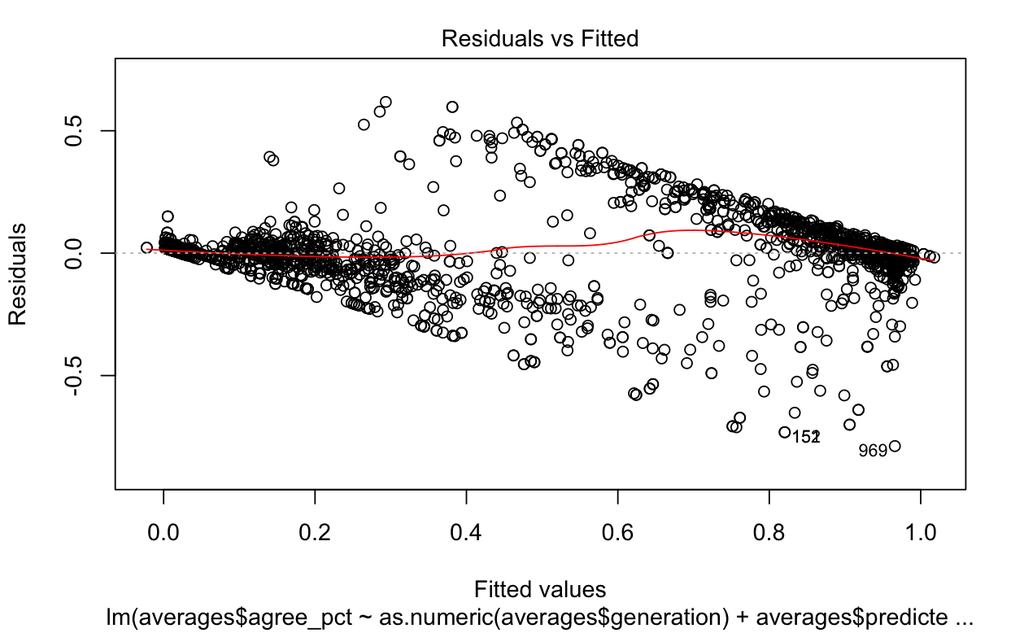

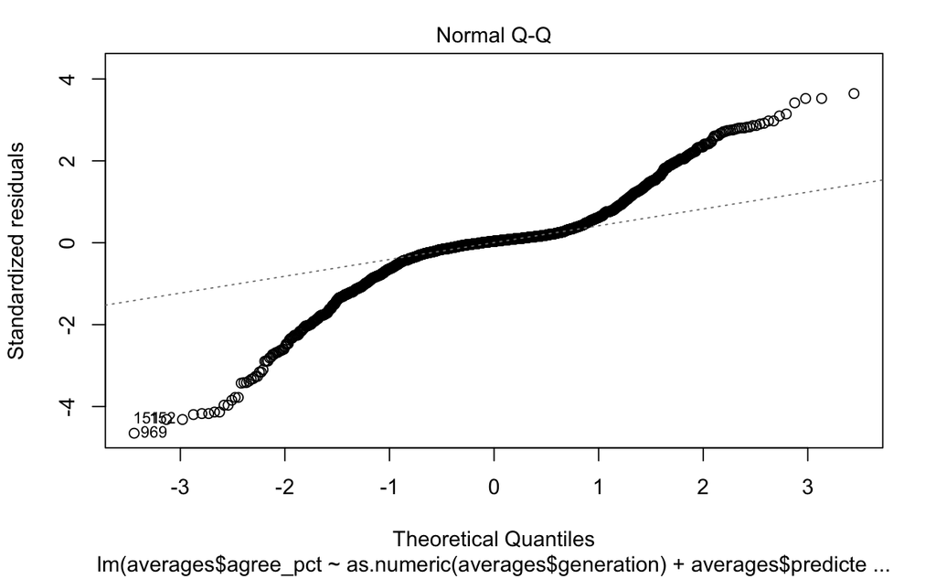

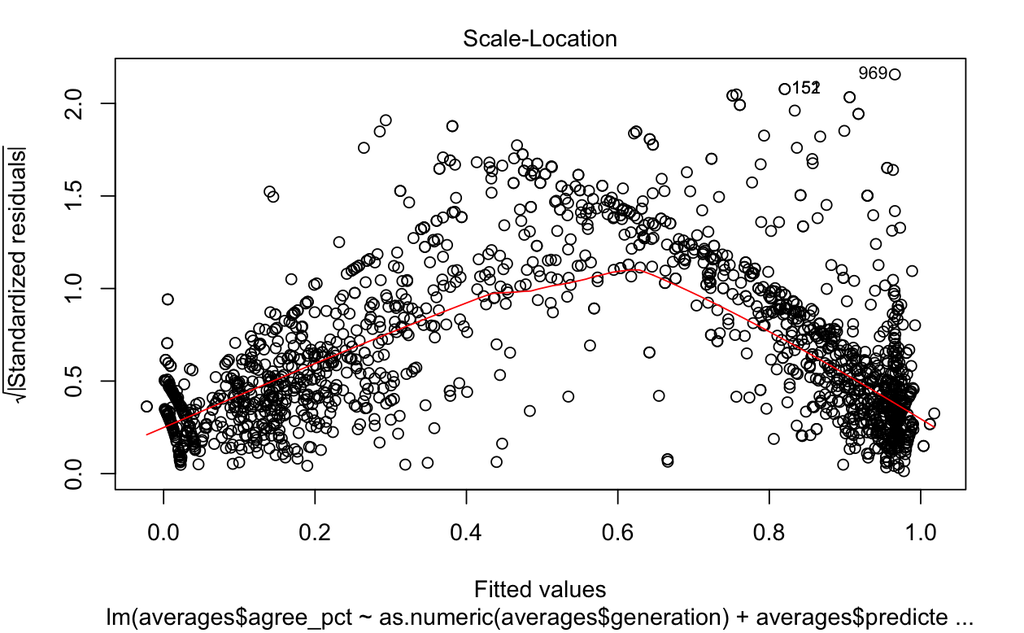

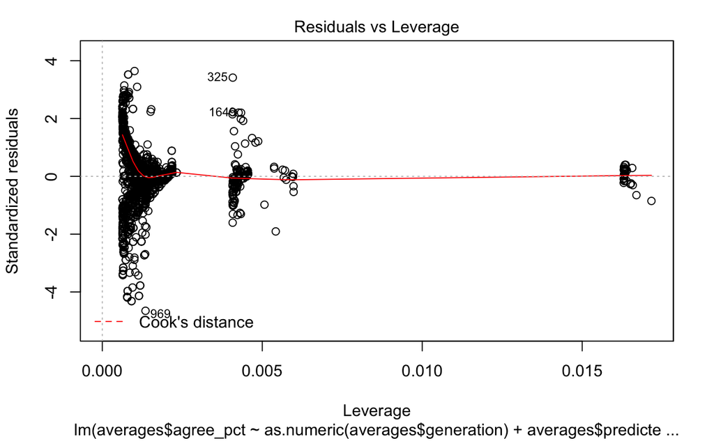

```r
plot(model)
```

```r
NA
NA
```

```r
set.seed(333)

index <- createDataPartition(averages$agree_pct, p = 0.75, list = FALSE)

train <- averages[index, ]
test <- averages[index, ]

trained_model <- lm(train, formula = agree_pct~predicted_agree+generation)
summary(trained_model)
```

```
Call:
lm(formula = agree_pct ~ predicted_agree + generation, data = train)

Residuals:
     Min       1Q   Median       3Q      Max
-0.73325 -0.04470  0.00561  0.04443  0.61725

Coefficients:
                 Estimate Std. Error t value Pr(>|t|)
(Intercept)     -0.014840   0.032004  -0.464    0.643
predicted_agree  1.042914   0.013389  77.895   <2e-16 ***
generation2     -0.006233   0.035984  -0.173    0.863
generation3     -0.007838   0.032729  -0.239    0.811
---
Signif. codes:  0 ‘***’ 0.001 ‘**’ 0.01 ‘*’ 0.05 ‘.’ 0.1 ‘ ’ 1

Residual standard error: 0.1628 on 1296 degrees of freedom
Multiple R-squared:  0.834, Adjusted R-squared:  0.8336
F-statistic:  2170 on 3 and 1296 DF,  p-value: < 2.2e-16
```

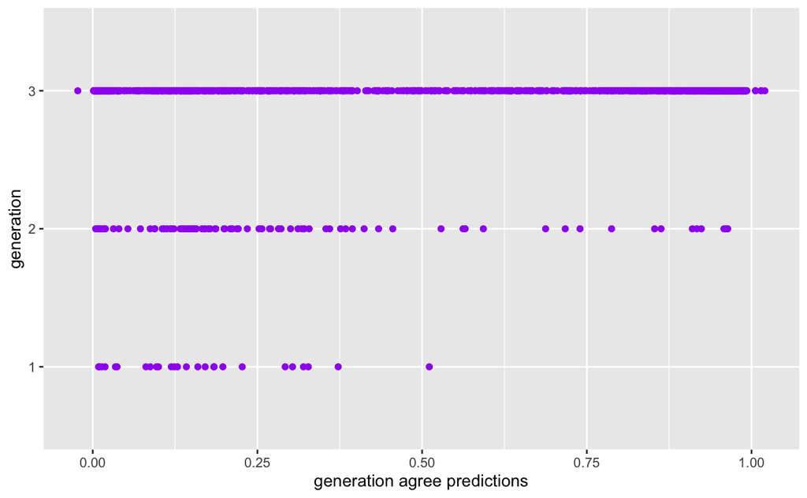

```r
generation_agree_predictions <- predict(trained_model, test)
ggplot(data=test, aes(generation_agree_predictions, generation)) + geom_point(color='purple') + xlab('generation agree predictions')
```